# Analysing viral phylogenies

Simon Frost

We are going to use a dataset of MERS-CoV analysed by Dudas et al. (2018) - the link is [here](https://elifesciences.org/articles/31257). I encourage you to read the paper. We will try to replicate some of the results today.

## Load libraries

We will need many libraries to fit these data. As a shortcut to install many of them you can run the following - this assumes you already have the library `devtools` installed.

```r
devtools::install_github("sdwfrost/mevr")
```

```r
library(ape) # reads in trees
library(magrittr) # adds 'pipe' operator
library(lubridate) # manipulates dates
library(treedater) # makes clock trees
library(skyspline) # infers population size
library(phydynR) # fits complex population models
library(diversitree) # fits 'mugration' models
library(phyland) # fits island models
library(adephylo) # provides distances to root
library(phangorn) # parsimony models
library(treeImbalance) # imbalance
```

```r
library(genieR) # parametric coalescent models
# the following need to be installed separately
# use setRepositories(ind=c(1,2)); install.packages(c("ggplot2","ggimage","magick","ggtree"))
library(ggplot2) # plotting
library(ggtree) # plotting phylogenies
library(magick)
library(ggimage)
```

## Read in tree

I have already generated a maximum likelihood tree for you, from a trimmed alignment that just covers the coding region of MERS.

```r
treefile <- "mers.treefile"
seqlen <- 29364
tre <- unroot(read.tree(treefile))
tipnames <- tre$tip.label
```

Check the tree has been read in properly.

```r
tre
```

```
##
## Phylogenetic tree with 274 tips and 272 internal nodes.
##
## Tip labels:
##  Jeddah-1_KF917527_camel_2013-11-08, Jeddah-1_KF958702_human_2013-11-05, Riyadh_3_2013_KF600613_human_2013-02-05, Riyadh_4_2013_KJ156952_human_2013-03-01, D1164.1_14_KX108937_camel_2014-06-02, UAE_D1164.11_2014_KP719929_camel_2014-06, ...
##
## Unrooted; includes branch lengths.
```

## Get sampling dates

In order to get a time-resolved tree, we need to extract the sampling dates, which can be of varying accuracy (year only, year and month, and full date).

```r
tipnames %>% strsplit(.,"_") %>% lapply(.,tail,1) %>% unlist -> tipdates
```

```r
tipdates
```

```
##   [1] "2013-11-08" "2013-11-05" "2013-02-05" "2013-03-01" "2014-06-02"
##   [6] "2014-06"    "2014-06"    "2014-06"    "2014-06"    "2013-11-15"
##  [11] "2013-10-28" "2013-12-30" "2013-11-30" "2013-12-30" "2013-12-28"
##  [16] "2014-03-07" "2014-04-10" "2014-04-10" "2014-04-13" "2014-04-19"
##  [21] "2014-04-07" "2014-04-17" "2015-01-30" "2014-12-13" "2015-02-14"
##  [26] "2015-02-15" "2015-02-12" "2014-06"    "2014-06"    "2014-06"
##  [31] "2014-03-12" "2014-03-04" "2013-04-26" "2013-06-12" "2013-08-05"
##  [36] "2013-11"    "2013-05-13" "2013-05-03" "2013-05-07" "2013-05-09"
##  [41] "2013-05-01" "2013-04-22" "2013-05-02" "2013-05-01" "2013-05-30"
##  [46] "2013-05-01" "2013-04-21" "2013-05-12" "2013-05-15" "2013-05-23"
##  [51] "2013-06-19" "2013-06-22" "2013-06-18" "2013-05-08" "2013-05-23"
##  [56] "2013-05-11" "2013-05-13" "2013-07-17" "2013-02-10" "2013-02-10"
##  [61] "2013-02-13" "2012-10-30" "2012-10-23" "2013-12-30" "2013-12-30"
##  [66] "2013-11-15" "2014-12-17" "2015-04-23" "2012-06-13" "2012-04-15"
##  [71] "2013-03-22" "2015-05-12" "2015-01-06" "2015-01-21" "2015-01-21"
```

[output cut: 40 more lines]

We can now look at the accuracy of the dates by the number of characters in the date.

```r
datelength <- nchar(tipdates)
table(datelength)
```

```
## datelength
##   7  10
##  79 195
```

This tells us we have 79 taxa with only year and month.

For now, we will simply impute this as day 15 of the month.

```r
tipdates2 <- tipdates
tipdates2[datelength==7] <- paste(tipdates[datelength==7],"-15",sep="")
```

For the computer to understand what to do with these dates, we need to convert them to decimal fractions of a year.

```r
decdates <- decimal_date(as.Date(tipdates2))
```

So that we know which sequence has which date, we also name these dates.

```r
names(decdates) <- tipnames
```

The command `head` gives us the first few entries, and everything seems to look OK.

```r
head(decdates)
```

```
##       Jeddah-1_KF917527_camel_2013-11-08
##                                 2013.852
##       Jeddah-1_KF958702_human_2013-11-05
##                                 2013.844
##  Riyadh_3_2013_KF600613_human_2013-02-05
##                                 2013.096
##  Riyadh_4_2013_KJ156952_human_2013-03-01
##                                 2013.162
##     D1164.1_14_KX108937_camel_2014-06-02
##                                 2014.416
## UAE_D1164.11_2014_KP719929_camel_2014-06
##                                 2014.452
```

## Root to tip regression

We can use R to perform root-to-tip regression as a quick check that there is enough temporal signal in the data. Note that the dates have to be in the same order as in the tip labels of the tree (which is true for the above code).

```r
tre.rtt <- rtt(tre,decdates)
```

To make the regression plot, we need to calculate the root to tip distances, as these aren’t returned by `rtt`.

```r
tree.rd <- distRoot(tre.rtt)
```

The tip labels of the rooted tree are not in the same order as our original tree, so we have to match up the tip labels of the tree with the dates.

```r
tree.td <- decdates[match(tre.rtt$tip.label,names(decdates))]
```

Now we have the root-to-tip distances and the sampling times, we create a data frame and plot, adding in a straight-line fit.

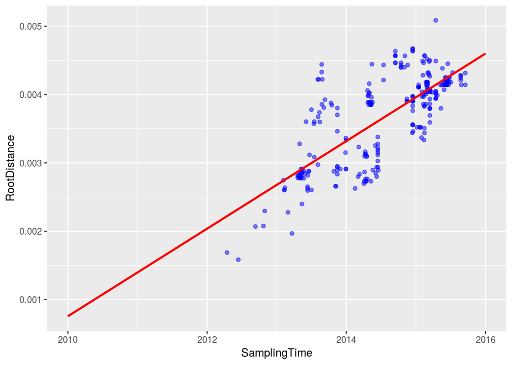

```r
rdtd <- data.frame(RootDistance=tree.rd,SamplingTime=tree.td)
p <- ggplot(rdtd,aes(x=SamplingTime,y=RootDistance))+geom_point(color="blue",alpha=0.5)+geom_smooth(method="lm",se=FALSE,fullrange=TRUE,color="red")+scale_x_continuous(limits=c(2010,2016))+theme(legend.position = "none")
p
```

The following code plots out a tree with the tips coloured by species using `ggtree`. The steps are as follows:

- Generate a data frame with the tip label and host type.
- Generate a `ggtree` and add on the dataframe using the `%<+%` operator
- Plot using the following options:
  - `theme_tree2`: puts in an x axis
  - `geom_tippoint`: adds in points at the tips, in this case, with the shape and colour determined by the host
  - `theme(legend.position="right")`: places the legent at the right
  - `scale_colour_manual`: sets the colours for the different hosts

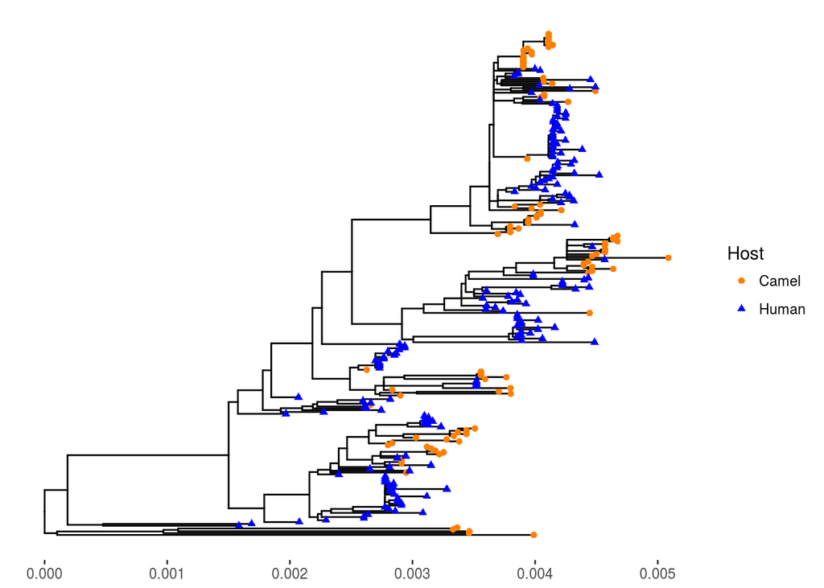

```r
h <- rep("Camel",length(tre.rtt$tip.label))
h[grep("human",tre.rtt$tip.label)] <- "Human"
dd <- data.frame(taxa=tre.rtt$tip.label,Host=h)
g1 <- ggtree(tre.rtt) %<+% dd
p <- g1+theme_tree2()+geom_tippoint(aes(shape=Host, color=Host), alpha=1.0)+theme(legend.position="right")+scale_color_manual(values=c(c("Camel"="darkorange1","Human"="blue")))
p
```

## Using treedater

There appears to be a reasonable temporal signal, so we now move on to generate a time-stamped phylogeny using treedater. The options below have the following interpretation:

- The first argument is the tree. If it is unrooted, as in the example below (c.f. `tre.rtt`), then `treedater` will try to find the best root.
- The second argument is the (decimal) sampling times. These do not have to be in the same order as the tree tip labels, but this has to be a named vector.
- `s`: the sequence length
- `minblen`: the minimum branch length (in units of time), in this case, 1 day
- `abstol`: the threshold for determining convergence of the algorithm
- `quiet`: whether to spool out parameter estimates during the run or not
- `temporalConstraints`: whether to include temporal constraints
- `numStart`: the number of starting values for parameter estimates.
- `searchRoot`: the number of trees (ranked by goodness of fit by `rtt`) to search
- `strictClock`: whether to use a strict clock rather than a relaxed clock
- `ncpu`: the number of cores to use

```r
tre.dated <- dater(tre, decdates, s=seqlen, maxit = 100, minblen=1./365, abstol = .001, quiet = TRUE, temporalConstraints=TRUE, numStart=2, searchRoot=2, strictClock=FALSE, ncpu=1)
```

We can print out the time of the most recent common ancestor.

```r
date_decimal(tre.dated$timeOfMRCA)
```

```
## [1] "2008-10-14 02:21:15 UTC"
```

We can now look at the new tree with tip dates on it.

```r
tre2 <- tre.dated
class(tre2) <- "phylo"
g <- ggtree(tre2,mrsd=date_decimal(max(decdates)))+theme_tree2()
```

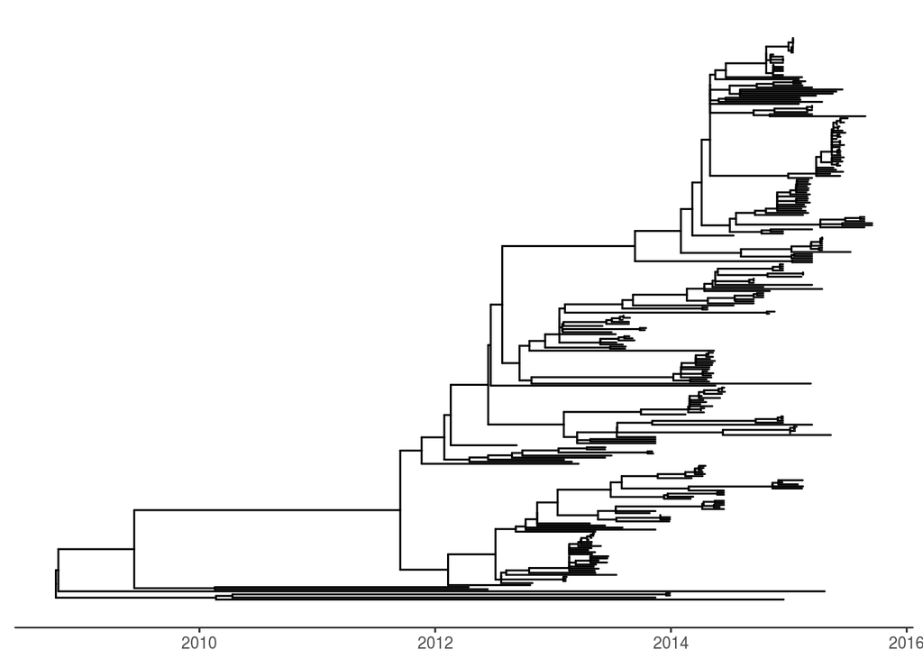

```r
g
```

## Changes in population size in camels

It doesn’t make much sense to look at a single ‘population size’ when we have a mixture of sequences from humans and camels. So, we will look just at camels.

### skyspline

We will prune the tree down to just camels using ‘drop.tip’. We also have to convert the tree into a `DatedTree`, which is the format for the next analysis.

```r
tre.camel <- drop.tip(tre2,grep("human",tre2$tip.label))
tre.dated.camel <- DatedTree(tre.camel, decdates[grep("camel",names(decdates))], tol = 1/365)
```

In order to calculate the population size from the tree, we use `skyspline`, which fits a non-parametric model to the ‘growth rate’ of the epidemic, and generates an estimate of the population size, rather than an effective population size. This requires an estimate of the death/recovery rate of the infection. We are uncertain of the duration of infectiousness of MERS in camels; for now, let us assume it is 10 days.

```r
t0 <- tre.dated.camel$maxSampleTime - tre.dated.camel$maxHeight
tre.dated.camel.sky <- fit.skyspline.ml(tre.dated.camel, death_rate_guess = 1/(10/365), t0=t0, y0_guess=1,  R0guess = 2, np_range = 6)
```

[output not shown]

[output cut: 13 more lines]

[output not shown]

```
## Number of spline points:
## [1] 6
```

The following extracts the population size (as `pop.size`) over time (as `times`) as a data frame.

```r
camel.popsize <- tre.dated.camel.sky$demo.history
```

We can now plot out the population size dynamics.

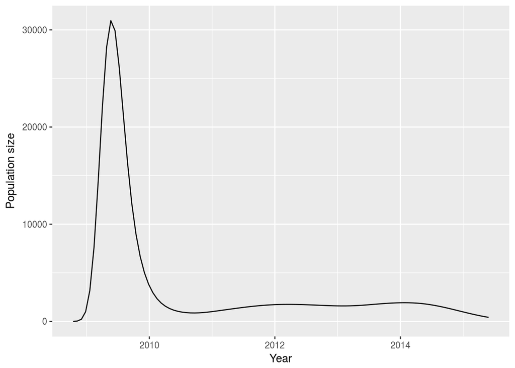

```r
ggplot(camel.popsize,aes(x=times,y=pop.size))+geom_line()+xlab("Year")+ylab("Population size")
```

Try changing the assumption about the infectious period in camels to 180 days (6 months) and replot the dynamics.

## Testing for deviations from the standard coalescent model

It is difficult to interpret the population size estimates from approaches such as `skyspline` if the assumption that the population is well-mixed and homogenous is broken. One way we can test this assumption is to create randomised trees in which the sampling and coalescence times are fixed, but the tree is otherwise permuted to remove any underlying structure. We can then compute summary statistics for the given tree and compare them to the permuted trees; a large deviation may indicate that a simple coalescent model may be insufficient.

The number of ‘cherries’ on the tree - a tip joined to another tip - is one measure of asymmetry. The lower the number of cherries, the more asymmetric the tree.

```r
tre.camel.cherries <- Ncherries(tre.camel)
tre.camel.cherries
```

```
## [1] 25
```

We now generate the permuted trees. For reproducibility purposes, it’s often a good idea to set the random number seed when performing such analyses.

```r
set.seed(1234)
simtrees <- list()
ntrees <- 200
for(i in 1:ntrees){
  simtrees[[i]] <- getSimTree(tre.camel)
}
```

As we have produced a list of trees, we can now use the `lapply` function to calculate the number of cherries for each tree in the list.

```r
simcherries <- lapply(simtrees,Ncherries) %>% unlist
```

An estimate of the p value can be obtained by calculating the proportion of simulations with the same or fewer cherries.

```r
sum(simcherries<=tre.camel.cherries)/ntrees
```

```
## [1] 0.12
```

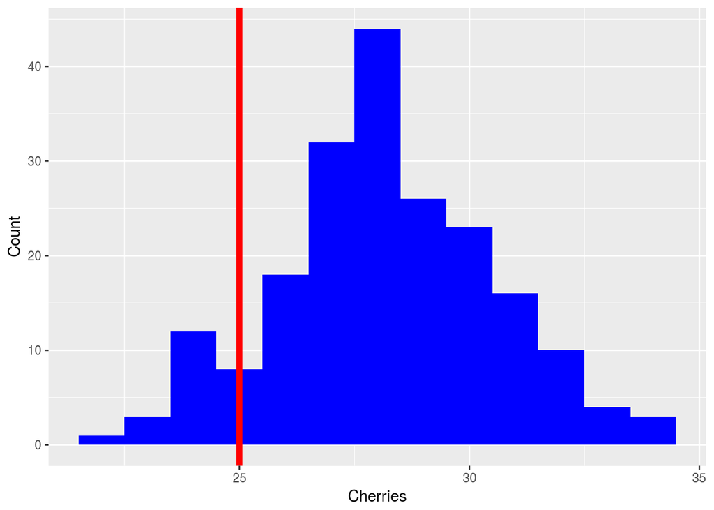

```r
ggplot(data.frame(Cherries=simcherries),aes(x=Cherries))+geom_histogram(binwidth=1,fill="blue")+xlab("Cherries")+ylab("Count")+geom_vline(xintercept=tre.camel.cherries,colour="red",lwd=2)
```

Another measure of asymmetry is Sackin’s index. We can calculate this using the following function.

```r
sack <- function(tr){
  sackin(as.treeshape(tr))
}
```

```r
tre.camel.sackin <- sack(tre.camel)
```

```r
simsackin <- lapply(simtrees,sack) %>% unlist
```

```r
sum(simsackin>=tre.camel.sackin)/ntrees
```

```
## [1] 0.01
```

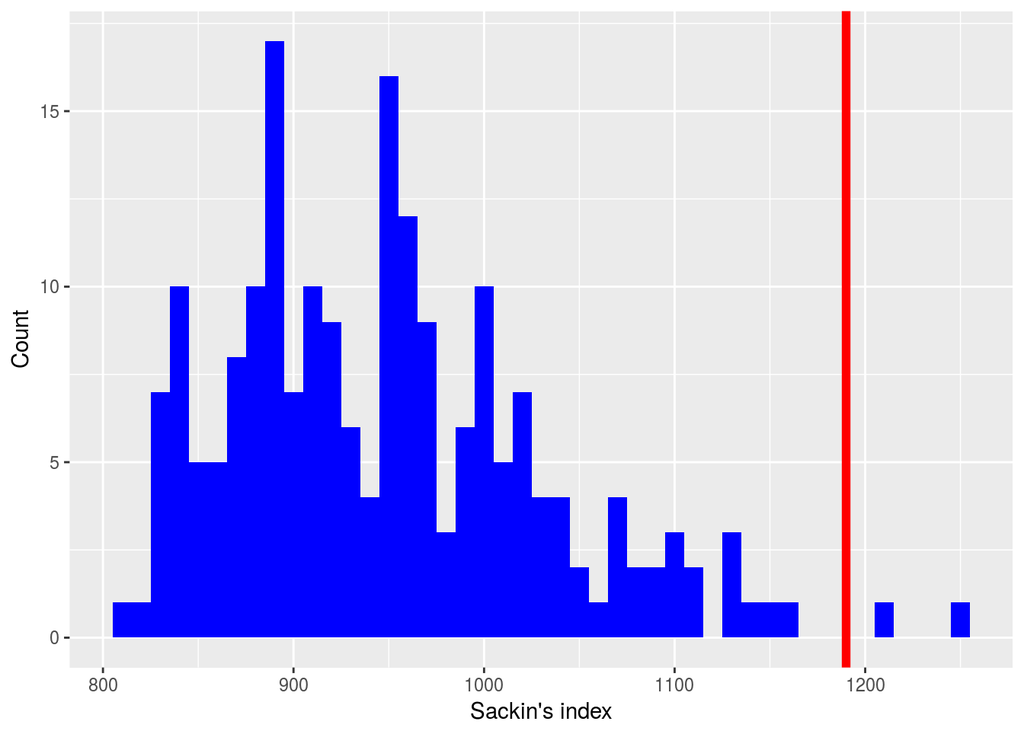

```r
ggplot(data.frame(Sackin=simsackin),aes(x=Sackin))+geom_histogram(binwidth=10,fill="blue")+xlab("Sackin's index")+ylab("Count")+geom_vline(xintercept=tre.camel.sackin,colour="red",lwd=2)
```

The assumption of a simple coalescent model appears to be broken, There’s more we can do in terms of trying to find exactly *how* the tree is different from the null, mostly by examining the dynamics of these statistics over time, but we won’t go into this now.

## Transmission between camels and humans

As we have two distinct subpopulations, camels and humans, we can investigate the relationship between them.

### Plotting the tree

We can colour the tree in by host type.

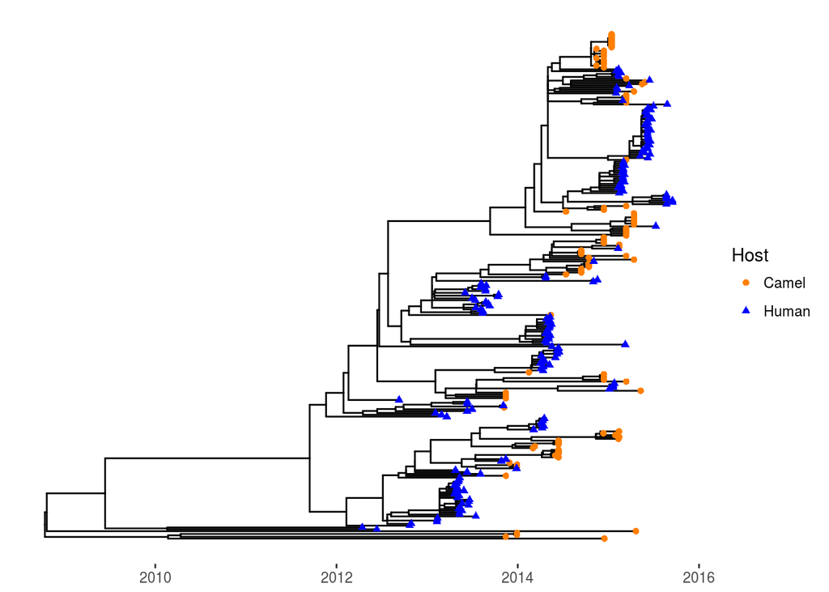

```r
host <- rep("Camel",length(tre2$tip.label))
host[grep("human",tre2$tip.label)] <- "Human"
dd <- data.frame(taxa=tre2$tip.label,Host=host)
g2 <- g %<+% dd
p <- g2+geom_tippoint(aes(shape=Host, color=Host), alpha=1.0)+theme(legend.position="right")+scale_color_manual(values=c(c("Camel"="darkorange1","Human"="blue")))
# ggsave("mers_treedater.png",p,width=8,height=5,units="in")
p
```

### Migration rates using a structured coalescent

```r
fit <- phylandml(tre2, delimiter=NULL, regex="camel|human",quiet=TRUE)
```

```r
fit
```

```
## Summary of log transformed parameters:
##                Estimate Std. Error z value Pr(z)
## camel         2.2620942         NA      NA    NA
## human         0.8139099         NA      NA    NA
## camel->human  1.0537785         NA      NA    NA
## human->camel -8.8607650         NA      NA    NA
##
## Design matrix
##       camel human
## camel    NA     3
## human     2    NA
##
## Estimated effective sizes and rates:
##
## camel        9.6031789317
## human        2.2567143449
## human->camel 0.0001418465
## camel->human 2.8684690786
```

The following incantation works out the probability of the root being in a camel or human.

```r
fit$ace[which.max(node.depth(fit$bdt )),]
```

```
##     camel        human
## 275     1 6.173649e-10
```

```r
fit$fit
```

```
##
## Call:
## bbmle::mle2(minuslogl = of0, start = theta0, method = method,
##     optimizer = "optim", skip.hessian = TRUE)
##
## Coefficients:
##        Ne1        Ne2   migrate2   migrate3
##  2.2620942  0.8139099  1.0537785 -8.8607650
##
## Log-likelihood: -801.41
```

```r
fit.infection <- phylandml(tre2, delimiter=NULL, regex="camel|human",model="infection",quiet=TRUE)
```

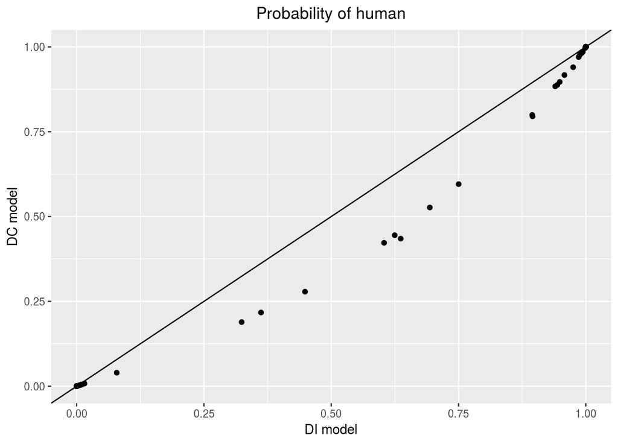

```r
p <- ggplot(data.frame(DC=fit.infection$ace$human,DI=fit$ace$human),aes(x=DI,y=DC))+geom_point()+geom_abline(slope=1,intercept=0)+xlab("DI model")+ylab("DC model")+ggtitle("Probability of human")+theme(plot.title = element_text(hjust = 0.5))
# ggsave("mers_dc_di.png",p,width=8,height=5,units="in")
p
```

## Appendix

For completeness, I provide code to calculate ‘migrations’ between camels and humans using parsimony and maximum likelihood, both of which give misleading results.

### Migration rates via parsimony

```r
host.data <- matrix(c(substr(host,1,1)),dimnames=list(c(tre2$tip.label),NULL),nrow=length(tre2$tip.label),byrow=T)
host.phydat <- phyDat(host.data,type="USER",levels=c("C","H"))
```

```r
anc.fitch <- ancestral.pars(tre2,host.phydat,type="MPR",cost=NULL)
```

```r
anc.sankoff.wrong <- ancestral.pars(tre2,host.phydat,type="MPR",cost=matrix(c(0,Inf,1,0),nrow=2,ncol=2))
anc.sankoff.right <- ancestral.pars(tre2,host.phydat,type="MPR",cost=matrix(c(0,1,Inf,0),nrow=2,ncol=2))
```

Jumps in the wrong direction.

```r
sankoff(tre2,host.phydat,cost=matrix(c(0,Inf,1,0)))
```

[output not shown]

```r
sankoff(tre2,host.phydat,cost=matrix(c(0,1,Inf,0)))
```

[output not shown]

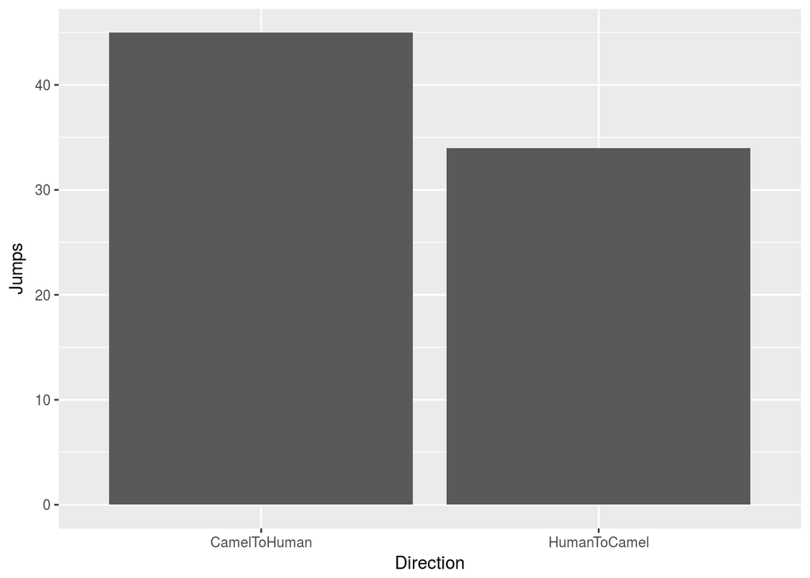

```r
p <- ggplot(data.frame(Direction=c("CamelToHuman","HumanToCamel"),Jumps=c(45,34)),aes(x=Direction,y=Jumps))+geom_bar(stat="identity")
# ggsave("mers_jumps.png",p,width=8,height=5,units="in")
p
```

```r
anc.sankoff.wrong.df <- data.frame(Camel=unname(unlist(lapply(anc.sankoff.wrong,"[",1))),Human=unname(unlist(lapply(anc.sankoff.wrong,"[",2))),node=names(anc.sankoff.wrong))
anc.sankoff.right.df <- data.frame(Camel=unname(unlist(lapply(anc.sankoff.right,"[",1))),Human=unname(unlist(lapply(anc.sankoff.right,"[",2))),node=names(anc.sankoff.right))
#anc.sankoff.wrong.df <- data.frame(Host=factor(unname(unlist(lapply(anc.sankoff.wrong,"[",1)))+1),node=names(anc.sankoff.wrong))
```

```r
g4 <- g2
pies <- nodepie(anc.sankoff.wrong.df,1:2,color=c("darkorange1","blue"),alpha=0.75)
p <- inset(g4,pies,width=0.05,height=0.05)
# ggsave("mers_pies.png",p,width=8,height=5,units="in")
p
```

[output not shown]

```r
g4 <- g2
pies <- nodepie(anc.sankoff.right.df,1:2,color=c("darkorange1","blue"),alpha=0.75)
p <- inset(g4,pies,width=0.05,height=0.05)
# ggsave("mers_pies_right.png",p,width=8,height=5,units="in")
p
```

[output not shown]

### Migration rates the WRONG way

```r
states <- as.integer(grepl("Human",host))
names(states) <- tre2$tip.label
head(states)
```

```
##       Jeddah-1_KF917527_camel_2013-11-08
##                                        0
##       Jeddah-1_KF958702_human_2013-11-05
##                                        1
##  Riyadh_3_2013_KF600613_human_2013-02-05
##                                        1
##  Riyadh_4_2013_KJ156952_human_2013-03-01
##                                        1
##     D1164.1_14_KX108937_camel_2014-06-02
##                                        0
## UAE_D1164.11_2014_KP719929_camel_2014-06
##                                        0
```

```r
check.tree <- function (tree, ultrametric = TRUE, bifurcating = TRUE, node.labels = FALSE)
{
    if (!inherits(tree, "phylo"))
        stop("'tree' must be a valid phylo tree")
    #if (ultrametric && !is.ultrametric(tree))
    #    stop("'tree' must be ultrametric")
    if (any(tree$edge.length < 0))
        stop("Negative branch lengths in tree")
    if (bifurcating && (!is.binary.tree(tree) || any(tabulate(tree$edge[,
        1]) == 1)))
        stop("'tree must be bifurcating (no polytomies or unbranched nodes)'")
    if (any(duplicated(tree$tip.label)))
        stop("Tree contains duplicated tip labels")
    if (node.labels) {
        if (is.null(tree$node.label))
            tree$node.label <- sprintf("nd%d", seq_len(tree$Nnode))
        else if (any(duplicated(tree$node.label)))
            stop("Tree contains duplicated node labels")
    }
    tree
}
assignInNamespace("check.tree",check.tree,"diversitree")
```

The following gives the rates of ‘mugration’:

- q01: camels to humans
- q10: humans to camels

```r
tre.mk2 <- make.mk2(tre2,states)
tre.mk2.fit <- find.mle(tre.mk2,c(0.1,0.1),root=ROOT.FLAT)
tre.mk2.fit$par
```

```
##       q01       q10
## 0.3107277 0.3655838
```

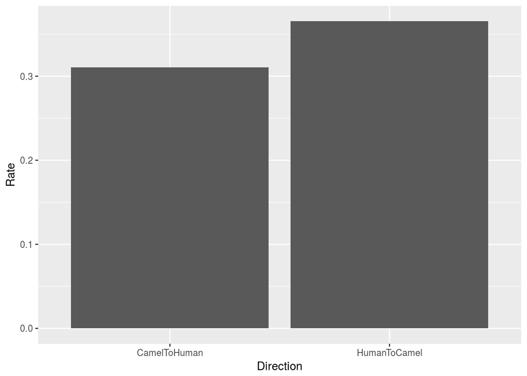

```r
p <- ggplot(data.frame(Direction=c("CamelToHuman","HumanToCamel"),Rate=c(tre.mk2.fit$par[1],tre.mk2.fit$par[2])),aes(x=Direction,y=Rate))+geom_bar(stat="identity")
# ggsave("mers_rates.png",p,width=8,height=5,units="in")
p
```

The following gives the probability of the root state being either in a camel or a human.

```r
mk2.root <- t(asr.marginal(tre.mk2,tre.mk2.fit$par))[1,]
names(mk2.root) <- c("camel","human")
mk2.root
```

```
##     camel     human
## 0.3826419 0.6173581
```

This is counter to our biological intuition, where we believe camels are the reservoir. Why is the model getting ‘tricked’?

```r
mk2.anc <- as.data.frame(t(asr.marginal(tre.mk2,tre.mk2.fit$par)))
mk2.anc$node <- as.character(seq(275,547))
head(mk2.anc)
```

```
##            V1        V2 node
## 1 0.382641920 0.6173581  275
## 2 0.167636419 0.8323636  276
## 3 0.007825661 0.9921743  277
## 4 0.002032587 0.9979674  278
## 5 0.001443519 0.9985565  279
## 6 0.001317355 0.9986826  280
```

```r
g4 <- g2
pies <- nodepie(mk2.anc,1:2,color=c("darkorange1","blue"),alpha=0.75)
p <- inset(g4,pies,width=0.05,height=0.05)+theme(legend.position="right")+scale_color_manual(values=c(c("V1"="darkorange1","V2"="blue")))
# ggsave("mers_pies_mk2.png",p,width=8,height=5,units="in")
```